# Meta-analysis of synesthetic metaphor tables

Bodo

2023-07-10

# 1 Introduction

This script looks at percent hierarchy consistency. Since this is our first analysis, we’ll also spend some time checking datasets to report overall statistics in the paper.

# 2 Setup

```r
library(tidyverse)     # for data processing and visualization
library(brms)          # for fitting bayesian models
library(tidybayes)     # for spread_draws()
```

Show R and package versions for computational reproducibility and reporting in paper:

```r
packageVersion('tidybayes')
```

```
## [1] '3.0.4'
```

Load the `both_tables` list that has been created in the `table_preprocessing.Rmd` file.

```r
# List of all tables:

load('../additional_data/all_included_tables_list.RData')
```

Show 5 random rows each to get an overview:

```r
# List of all tables:

both_tables[sample(1:length(both_tables), 5)]
```

```
## $whitney_1952_kosztolanyi
##         touch taste smell hearing sight
## touch      NA     1     4      17    10
## taste       3    NA     2       3     5
## smell       0     0    NA       2     1
## hearing     5     0     1      NA    15
## sight       6     0     1      20    NA
##
## $mancas_1962_sadoveanu
##         touch taste smell hearing sight
## touch      NA     0     5     152    58
## taste       9    NA    10      74    45
## smell       1     0    NA       0     3
## hearing     0     0     0      NA     3
## sight       2     0     3      58    NA
##
## $whitney_1952_babits
##         touch taste smell hearing sight
## touch      NA     2     2      34    37
## taste       2    NA     6       7     8
## smell       1     1    NA       5     0
## hearing     7     2     6      NA    27
## sight       0     1     0      37    NA
##
## $day_1996_german_buddenbrooks
##         touch taste smell hearing sight
## touch      NA     1     8     131     3
## taste       0    NA     4       9     2
## smell       1     0    NA       0     0
## hearing     0     0     0      NA     3
## sight       1     0     0      12    NA
##
## $catricalà_2008_spanish
##         touch taste smell hearing sight
## touch      NA     2     1      10     9
## taste       0    NA     2       2     2
## smell       0     0    NA       0     0
## hearing     2     0     0      NA     6
## sight       0     0     0      10    NA
```

Load metadata and rename columns as desired:

```r
metadata <- read_csv('../metadata.csv') %>%
  rename(genre = Genre,
         language = `Language of data`,
         source = `Type of data source`,
         table_title = `Table title`)
```

# 3 Compute source/target ratios

Let’s compute the source-target ratios. This is a fairly intuitive quantity: for touch, for example, we look at the row totals — how often it is used as a source — and divide this by the column totals — how often it us used as a target. The corresponding ratio quantifies how much more something is used as a source.

```r
# Setup tibble with empty columns:

ratios <- tibble(dataset = names(both_tables),
                 touch = NA,
                 taste = NA,
                 smell = NA,
                 sight = NA,
                 sound = NA)

# Loop through tables, compute proportions, and save in results table:

for (i in seq_along(both_tables)) {
  # Extract table from list and transform into matrix object without first column:

  M <- both_tables[[i]]

  # All ratios:

  these_ratios <- rowSums(M, na.rm = TRUE) / colSums(M, na.rm = TRUE)

  # Get the hierarchy consistent cases and divide by sum:

  ratios[i, ]$touch <- these_ratios['touch']
  ratios[i, ]$taste <- these_ratios['taste']
  ratios[i, ]$smell <- these_ratios['smell']
  ratios[i, ]$sound <- these_ratios['hearing']
  ratios[i, ]$sight <- these_ratios['sight']
}
```

Check table:

```r
ratios
```

```
## # A tibble: 38 × 6
##    dataset                                touch  taste  smell sight  sound
##    <chr>                                  <dbl>  <dbl>  <dbl> <dbl>  <dbl>
##  1 bretones-callejas_2001_heaney           4      1.5  2      1.5   0.105
##  2 day_1996_english                       22.3   39.4  0.0169 0.413 0.0421
##  3 day_1996_german_buddenbrooks           71.5   15    0.0833 1.62  0.0197
##  4 doetsch_kraus_1992_1                   11.6   20.5  0.354  0.454 0.0980
##  5 jo_2017_korean                         12.3    6.6  0.188  0.769 0.14
##  6 jo_2022_korean                         15      6.75 0.1    0.768 0.118
##  7 kumcu_2021_turkish                      9.40  24.3  0.120  1.02  0.0320
##  8 mancas_1962_arghezi                     4.25 Inf    1      0.340 0.517
##  9 mancas_1962_Eminescu_poetry_in_vita     2.64 Inf    1      0.18  0.0189
## 10 mancas_1962_Eminescu_poetry_posthumous  6.62  77    0.667  0.129 0.0227
## # ℹ 28 more rows
```

The `Inf` cases result from division by zero for cases where something is only used as a source, but never as a target (= 0). Let’s set these to `NA` as the true ratio cannot be known in this case.

```r
# Define helper function:

inf_to_NA <- function(x) ifelse(is.infinite(x), NA, x)

# Apply this function to all numeric ("double") columns:

ratios <- ratios %>%
  mutate(across(where(is.double), inf_to_NA))

# Check:

ratios
```

```
## # A tibble: 38 × 6
##    dataset                                touch taste  smell sight  sound
##    <chr>                                  <dbl> <dbl>  <dbl> <dbl>  <dbl>
##  1 bretones-callejas_2001_heaney           4     1.5  2      1.5   0.105
##  2 day_1996_english                       22.3  39.4  0.0169 0.413 0.0421
##  3 day_1996_german_buddenbrooks           71.5  15    0.0833 1.62  0.0197
##  4 doetsch_kraus_1992_1                   11.6  20.5  0.354  0.454 0.0980
##  5 jo_2017_korean                         12.3   6.6  0.188  0.769 0.14
##  6 jo_2022_korean                         15     6.75 0.1    0.768 0.118
##  7 kumcu_2021_turkish                      9.40 24.3  0.120  1.02  0.0320
##  8 mancas_1962_arghezi                     4.25 NA    1      0.340 0.517
##  9 mancas_1962_Eminescu_poetry_in_vita     2.64 NA    1      0.18  0.0189
## 10 mancas_1962_Eminescu_poetry_posthumous  6.62 77    0.667  0.129 0.0227
## # ℹ 28 more rows
```

Seems to have worked.

Make that into a long format table so we can plot it:

```r
ratios_long <- ratios %>%
  pivot_longer(cols = touch:sound,
               names_to = 'modality',
               values_to = 'ratio')

# Check:

ratios_long
```

```
## # A tibble: 190 × 3
##    dataset                       modality   ratio
##    <chr>                         <chr>      <dbl>
##  1 bretones-callejas_2001_heaney touch     4
##  2 bretones-callejas_2001_heaney taste     1.5
##  3 bretones-callejas_2001_heaney smell     2
##  4 bretones-callejas_2001_heaney sight     1.5
##  5 bretones-callejas_2001_heaney sound     0.105
##  6 day_1996_english              touch    22.3
##  7 day_1996_english              taste    39.4
##  8 day_1996_english              smell     0.0169
##  9 day_1996_english              sight     0.413
## 10 day_1996_english              sound     0.0421
## # ℹ 180 more rows
```

We’ll later use log ratios as well for plotting (ratios can easily get skewed if the denominators are small, making it hard to see patterns).

```r
ratios_long <- mutate(ratios_long,
                      log_ratio = log(ratio),
                      log_ratio = inf_to_NA(log_ratio))
```

# 4 Ratio averages and plots

Check averages:

```r
ratios_long %>%
  group_by(modality) %>%
  summarize(mean_ratio = mean(ratio, na.rm = TRUE),
            log_ratio = mean(log_ratio, na.rm = TRUE))
```

```
## # A tibble: 5 × 3
##   modality mean_ratio log_ratio
##   <chr>         <dbl>     <dbl>
## 1 sight         0.984    -0.393
## 2 smell         0.400    -1.32
## 3 sound         0.176    -2.20
## 4 taste        11.0       1.75
## 5 touch        20.3       2.37
```

Make the order of the `modality` factor roughly correspond to the hierarchy for plotting purposes:

```r
# Define vector with desired order:

level_order <- c('touch', 'taste', 'smell', 'sight', 'sound')

# Make column into factor with those levels:

ratios_long <- mutate(ratios_long,
                      modality = factor(modality,
                                        levels = level_order))
```

Make a plot of this:

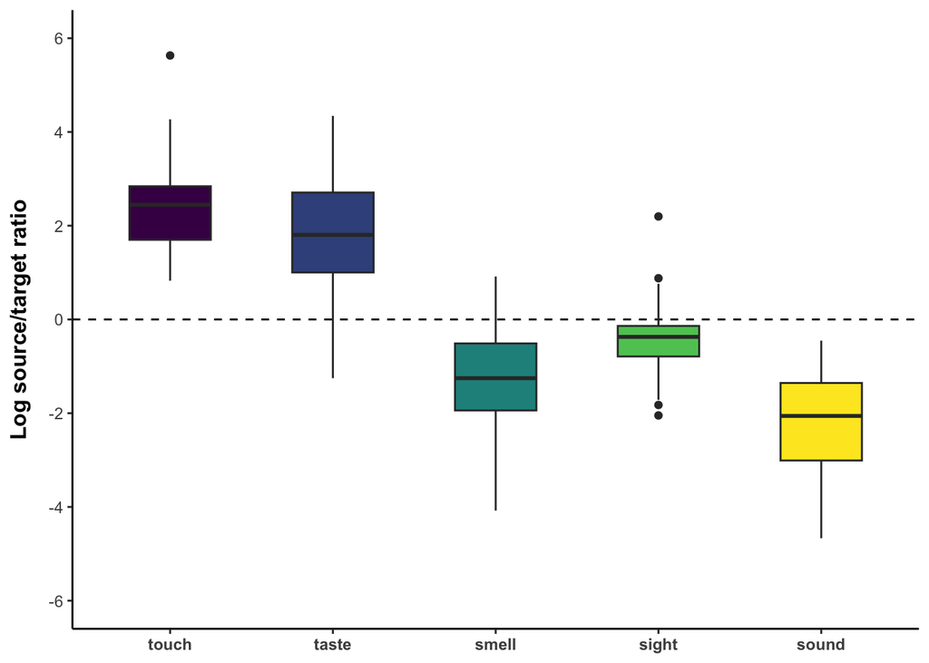

```r
# Core of plot:

ratio_p <- ratios_long %>%
  ggplot(aes(x = modality,
             y = log_ratio,
             fill = modality)) +
  geom_hline(yintercept = 0, linetype = 'dashed') +
  geom_boxplot(width = 0.5)

# Add annotations, axes, labels to plot:

ratio_p <- ratio_p +
  xlab(NULL) +
  ylab('Log source/target ratio') +
  scale_fill_viridis_d(option = 'D') +
  scale_y_continuous(limits = c(-6, 6),
                     breaks = seq(-6, 6, 2))

# Cosmetic tweaking:

ratio_p <- ratio_p +
  theme_classic() +
  theme(legend.position = 'none',
        axis.text.x = element_text(face = 'bold'),
        axis.title = element_text(face = 'bold',
                                  size = 12),
        axis.title.y = element_text(margin = margin(r = 10)))

# Show plot in markdown and also save externally outside of R:

ratio_p
```

```r
ggsave(plot = ratio_p,
       filename = '../figures/pdf/source_target_ratios.pdf',
       width = 5.2, height = 4.5)
ggsave(plot = ratio_p,
       filename = '../figures/png/source_target_ratios.png',
       width = 5.2, height = 4.5)
```

# 5 Bayesian model of ratios

How are the log ratios themselves distributed? This could inform a choice of model.

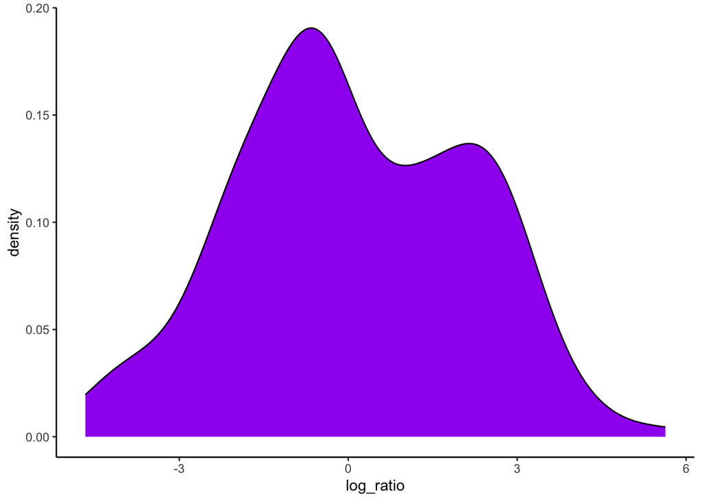

```r
ratios_long %>%
  ggplot(aes(x = log_ratio)) +
  geom_density(fill = 'purple') +
  theme_classic()
```

Ok, I wouldn’t be too opposed to using a Gaussian model in this case as a first pass, and see how far we can go with this. We should add the language metadata to the table though so that we can have a language random effect.

```r
ratios_long <- left_join(ratios_long,
                         select(metadata, table_title, genre, language),
                         by = c('dataset' = 'table_title'))
```

Set priors. Since we’ll have random slopes for this model (each language has five data points now, one per modality, so we can fit by-language modality random slopes), we now also need LKJ priors for the random effects correlation matrix.

```r
my_priors <- c(prior(normal(0, 1), class = Intercept),
               prior(normal(0, 1), class = b),
               prior(student_t(3, 0, 2.5), class = sd), # df = 3, mu = 0, sigma = 2.5
               prior(lkj(2), class = cor))
```

Fit a Gaussian model then:

```r
ratio_mdl <- brm(log_ratio ~

                  # Fixed effects:

                  1 + modality +

                  # Random effects:

                  (1 + modality|language),

                data = ratios_long,
                family = gaussian,

                # Priors:

                prior = my_priors,

                # MCMC settings:

                seed = 42,
                cores = 4,
                chains = 4,
                iter = 6000,
                warmup = 4000,
                control = list(adapt_delta = 0.99),
                save_pars = save_pars(all = TRUE))
```

```
## Trying to compile a simple C file
```

[output not shown]

```r
# Save the model:

save(ratio_mdl, file = '../models/ratio_model.RData')
```

Load the pre-compiled model:

```r
load('../models/ratio_model.RData')
```

Assess whether this is a plausible data-generating process:

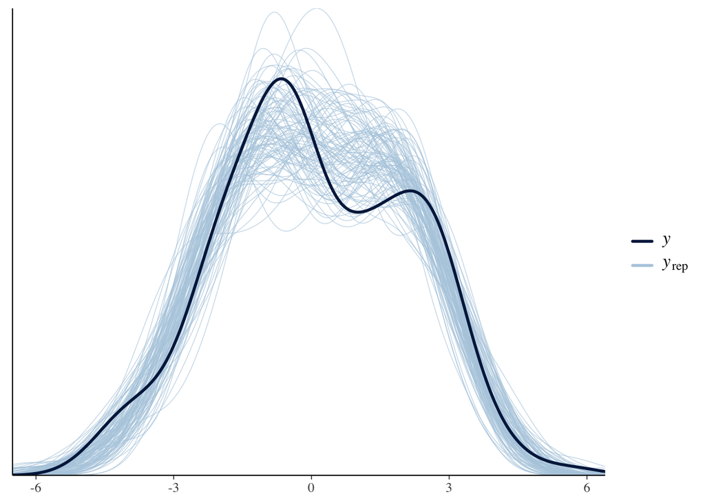

```r
pp_check(ratio_mdl, ndraws = 100)
```

Looks quite good!

Check the model:

```r
ratio_mdl
```

```
##  Family: gaussian
##   Links: mu = identity; sigma = identity
## Formula: log_ratio ~ 1 + modality + (1 + modality | language)
##    Data: ratios_long (Number of observations: 174)
##   Draws: 4 chains, each with iter = 6000; warmup = 4000; thin = 1;
##          total post-warmup draws = 8000
##
## Group-Level Effects:
## ~language (Number of levels: 14)
##                                  Estimate Est.Error l-95% CI u-95% CI Rhat
## sd(Intercept)                        0.14      0.11     0.00     0.41 1.00
## sd(modalitytaste)                    0.66      0.44     0.03     1.62 1.00
## sd(modalitysmell)                    0.39      0.30     0.02     1.12 1.00
## sd(modalitysight)                    0.35      0.26     0.02     0.95 1.00
## sd(modalitysound)                    0.86      0.46     0.17     2.00 1.00
## cor(Intercept,modalitytaste)        -0.09      0.36    -0.73     0.62 1.00
## cor(Intercept,modalitysmell)        -0.09      0.36    -0.74     0.61 1.00
## cor(modalitytaste,modalitysmell)     0.08      0.35    -0.61     0.71 1.00
## cor(Intercept,modalitysight)        -0.06      0.36    -0.71     0.62 1.00
## cor(modalitytaste,modalitysight)    -0.14      0.36    -0.76     0.60 1.00
## cor(modalitysmell,modalitysight)    -0.06      0.35    -0.69     0.61 1.00
## cor(Intercept,modalitysound)        -0.00      0.36    -0.68     0.67 1.00
## cor(modalitytaste,modalitysound)    -0.16      0.34    -0.76     0.54 1.00
## cor(modalitysmell,modalitysound)     0.03      0.34    -0.62     0.67 1.00
## cor(modalitysight,modalitysound)     0.07      0.35    -0.61     0.71 1.00
##                                  Bulk_ESS Tail_ESS
## sd(Intercept)                        3877     3550
## sd(modalitytaste)                    1510     1717
## sd(modalitysmell)                    2890     3078
## sd(modalitysight)                    3170     3937
## sd(modalitysound)                    2018     2297
## cor(Intercept,modalitytaste)         3698     4985
## cor(Intercept,modalitysmell)         5561     5522
## cor(modalitytaste,modalitysmell)     8058     5930
## cor(Intercept,modalitysight)         7015     5617
## cor(modalitytaste,modalitysight)     6501     5852
## cor(modalitysmell,modalitysight)     6968     6030
## cor(Intercept,modalitysound)         3913     4715
## cor(modalitytaste,modalitysound)     3695     4929
## cor(modalitysmell,modalitysound)     4515     6106
## cor(modalitysight,modalitysound)     4747     6473
##
## Population-Level Effects:
##               Estimate Est.Error l-95% CI u-95% CI Rhat Bulk_ESS Tail_ESS
## Intercept         2.08      0.17     1.75     2.41 1.00     7270     5945
## modalitytaste    -0.36      0.33    -1.02     0.30 1.00     4716     5320
## modalitysmell    -3.26      0.29    -3.79    -2.63 1.00     4738     3790
## modalitysight    -2.34      0.27    -2.85    -1.77 1.00     5899     5381
## modalitysound    -3.95      0.43    -4.66    -2.95 1.00     3003     2746
##
## Family Specific Parameters:
##       Estimate Est.Error l-95% CI u-95% CI Rhat Bulk_ESS Tail_ESS
## sigma     1.03      0.06     0.91     1.16 1.00     5462     5027
##
## Draws were sampled using sampling(NUTS). For each parameter, Bulk_ESS
## and Tail_ESS are effective sample size measures, and Rhat is the potential
## scale reduction factor on split chains (at convergence, Rhat = 1).
```

Touch is the reference level in the intercept. We can test whether taste, smell, sight and sound differ in terms of their source-target ratios, and how uncertain those differences are.

```r
hypothesis(ratio_mdl, 'modalitytaste > 0')
```

```
## Hypothesis Tests for class b:
##            Hypothesis Estimate Est.Error CI.Lower CI.Upper Evid.Ratio Post.Prob
## 1 (modalitytaste) > 0    -0.36      0.33    -0.89     0.18       0.14      0.12
##   Star
## 1
## ---
## 'CI': 90%-CI for one-sided and 95%-CI for two-sided hypotheses.
## '*': For one-sided hypotheses, the posterior probability exceeds 95%;
## for two-sided hypotheses, the value tested against lies outside the 95%-CI.
## Posterior probabilities of point hypotheses assume equal prior probabilities.
```

```r
hypothesis(ratio_mdl, 'modalitysmell < 0')
```

```
## Hypothesis Tests for class b:
##            Hypothesis Estimate Est.Error CI.Lower CI.Upper Evid.Ratio Post.Prob
## 1 (modalitysmell) < 0    -3.26      0.29    -3.71    -2.77        Inf         1
##   Star
## 1    *
## ---
## 'CI': 90%-CI for one-sided and 95%-CI for two-sided hypotheses.
## '*': For one-sided hypotheses, the posterior probability exceeds 95%;
## for two-sided hypotheses, the value tested against lies outside the 95%-CI.
## Posterior probabilities of point hypotheses assume equal prior probabilities.
```

```r
hypothesis(ratio_mdl, 'modalitysight < 0')
```

```
## Hypothesis Tests for class b:
##            Hypothesis Estimate Est.Error CI.Lower CI.Upper Evid.Ratio Post.Prob
## 1 (modalitysight) < 0    -2.34      0.27    -2.78    -1.88        Inf         1
##   Star
## 1    *
## ---
## 'CI': 90%-CI for one-sided and 95%-CI for two-sided hypotheses.
## '*': For one-sided hypotheses, the posterior probability exceeds 95%;
## for two-sided hypotheses, the value tested against lies outside the 95%-CI.
## Posterior probabilities of point hypotheses assume equal prior probabilities.
```

```r
hypothesis(ratio_mdl, 'modalitysound < 0')
```

```
## Hypothesis Tests for class b:
##            Hypothesis Estimate Est.Error CI.Lower CI.Upper Evid.Ratio Post.Prob
## 1 (modalitysound) < 0    -3.95      0.43    -4.54     -3.2        Inf         1
##   Star
## 1    *
## ---
## 'CI': 90%-CI for one-sided and 95%-CI for two-sided hypotheses.
## '*': For one-sided hypotheses, the posterior probability exceeds 95%;
## for two-sided hypotheses, the value tested against lies outside the 95%-CI.
## Posterior probabilities of point hypotheses assume equal prior probabilities.
```

We can also look at whether the smell coefficient differed reliably from the sight and sound coefficients, and from each other.

```r
hypothesis(ratio_mdl, 'modalitysmell < modalitytaste')
```

```
## Hypothesis Tests for class b:
##                 Hypothesis Estimate Est.Error CI.Lower CI.Upper Evid.Ratio
## 1 (modalitysmell)-(... < 0     -2.9      0.38    -3.49    -2.25        Inf
##   Post.Prob Star
## 1         1    *
## ---
## 'CI': 90%-CI for one-sided and 95%-CI for two-sided hypotheses.
## '*': For one-sided hypotheses, the posterior probability exceeds 95%;
## for two-sided hypotheses, the value tested against lies outside the 95%-CI.
## Posterior probabilities of point hypotheses assume equal prior probabilities.
```

```r
hypothesis(ratio_mdl, 'modalitytaste > modalitysmell')
```

```
## Hypothesis Tests for class b:
##                 Hypothesis Estimate Est.Error CI.Lower CI.Upper Evid.Ratio
## 1 (modalitytaste)-(... > 0      2.9      0.38     2.25     3.49        Inf
##   Post.Prob Star
## 1         1    *
## ---
## 'CI': 90%-CI for one-sided and 95%-CI for two-sided hypotheses.
## '*': For one-sided hypotheses, the posterior probability exceeds 95%;
## for two-sided hypotheses, the value tested against lies outside the 95%-CI.
## Posterior probabilities of point hypotheses assume equal prior probabilities.
```

```r
hypothesis(ratio_mdl, 'modalitysmell < modalitysight')
```

```
## Hypothesis Tests for class b:
##                 Hypothesis Estimate Est.Error CI.Lower CI.Upper Evid.Ratio
## 1 (modalitysmell)-(... < 0    -0.91      0.34    -1.45    -0.36     139.35
##   Post.Prob Star
## 1      0.99    *
## ---
## 'CI': 90%-CI for one-sided and 95%-CI for two-sided hypotheses.
## '*': For one-sided hypotheses, the posterior probability exceeds 95%;
## for two-sided hypotheses, the value tested against lies outside the 95%-CI.
## Posterior probabilities of point hypotheses assume equal prior probabilities.
```

```r
hypothesis(ratio_mdl, 'modalitysmell > modalitysound')
```

```
## Hypothesis Tests for class b:
##                 Hypothesis Estimate Est.Error CI.Lower CI.Upper Evid.Ratio
## 1 (modalitysmell)-(... > 0      0.7      0.47     -0.1     1.38      13.73
##   Post.Prob Star
## 1      0.93
## ---
## 'CI': 90%-CI for one-sided and 95%-CI for two-sided hypotheses.
## '*': For one-sided hypotheses, the posterior probability exceeds 95%;
## for two-sided hypotheses, the value tested against lies outside the 95%-CI.
## Posterior probabilities of point hypotheses assume equal prior probabilities.
```

```r
hypothesis(ratio_mdl, 'modalitysight > modalitysound')
```

```
## Hypothesis Tests for class b:
##                 Hypothesis Estimate Est.Error CI.Lower CI.Upper Evid.Ratio
## 1 (modalitysight)-(... > 0     1.61      0.45     0.83     2.26     180.82
##   Post.Prob Star
## 1      0.99    *
## ---
## 'CI': 90%-CI for one-sided and 95%-CI for two-sided hypotheses.
## '*': For one-sided hypotheses, the posterior probability exceeds 95%;
## for two-sided hypotheses, the value tested against lies outside the 95%-CI.
## Posterior probabilities of point hypotheses assume equal prior probabilities.
```

Or whether each condition is above zero.

```r
hypothesis(ratio_mdl, 'Intercept > 0') # touch
```

```
## Hypothesis Tests for class b:
##        Hypothesis Estimate Est.Error CI.Lower CI.Upper Evid.Ratio Post.Prob
## 1 (Intercept) > 0     2.08      0.17      1.8     2.36        Inf         1
##   Star
## 1    *
## ---
## 'CI': 90%-CI for one-sided and 95%-CI for two-sided hypotheses.
## '*': For one-sided hypotheses, the posterior probability exceeds 95%;
## for two-sided hypotheses, the value tested against lies outside the 95%-CI.
## Posterior probabilities of point hypotheses assume equal prior probabilities.
```

```r
hypothesis(ratio_mdl, 'Intercept + modalitytaste  > 0') # taste
```

```
## Hypothesis Tests for class b:
##                 Hypothesis Estimate Est.Error CI.Lower CI.Upper Evid.Ratio
## 1 (Intercept+modali... > 0     1.73      0.29     1.25      2.2        Inf
##   Post.Prob Star
## 1         1    *
## ---
## 'CI': 90%-CI for one-sided and 95%-CI for two-sided hypotheses.
## '*': For one-sided hypotheses, the posterior probability exceeds 95%;
## for two-sided hypotheses, the value tested against lies outside the 95%-CI.
## Posterior probabilities of point hypotheses assume equal prior probabilities.
```

```r
hypothesis(ratio_mdl, 'Intercept + modalitysmell  < 0') # smell
```

```
## Hypothesis Tests for class b:
##                 Hypothesis Estimate Est.Error CI.Lower CI.Upper Evid.Ratio
## 1 (Intercept+modali... < 0    -1.17      0.25    -1.55    -0.75    1332.33
##   Post.Prob Star
## 1         1    *
## ---
## 'CI': 90%-CI for one-sided and 95%-CI for two-sided hypotheses.
## '*': For one-sided hypotheses, the posterior probability exceeds 95%;
## for two-sided hypotheses, the value tested against lies outside the 95%-CI.
## Posterior probabilities of point hypotheses assume equal prior probabilities.
```

```r
hypothesis(ratio_mdl, 'Intercept + modalitysight  < 0') # sight
```

```
## Hypothesis Tests for class b:
##                 Hypothesis Estimate Est.Error CI.Lower CI.Upper Evid.Ratio
## 1 (Intercept+modali... < 0    -0.26      0.22     -0.6     0.12       7.57
##   Post.Prob Star
## 1      0.88
## ---
## 'CI': 90%-CI for one-sided and 95%-CI for two-sided hypotheses.
## '*': For one-sided hypotheses, the posterior probability exceeds 95%;
## for two-sided hypotheses, the value tested against lies outside the 95%-CI.
## Posterior probabilities of point hypotheses assume equal prior probabilities.
```

```r
hypothesis(ratio_mdl, 'Intercept + modalitysound  < 0') # sound
```

```
## Hypothesis Tests for class b:
##                 Hypothesis Estimate Est.Error CI.Lower CI.Upper Evid.Ratio
## 1 (Intercept+modali... < 0    -1.87      0.41    -2.42    -1.14     362.64
##   Post.Prob Star
## 1         1    *
## ---
## 'CI': 90%-CI for one-sided and 95%-CI for two-sided hypotheses.
## '*': For one-sided hypotheses, the posterior probability exceeds 95%;
## for two-sided hypotheses, the value tested against lies outside the 95%-CI.
## Posterior probabilities of point hypotheses assume equal prior probabilities.
```

We can compare this to a model that only knows about whether the sense is lower or higher, thus collapsing sight/sound under higher and touch/taste/smell under lower. If this model performs worse, then this is evidence that it’s better to look at specific modalities.

```r
ratios_long <- ratios_long %>%
  mutate(hierarchy = ifelse(modality %in% c('sight', 'sound'),
                            'higher', # if
                            'lower')) # else

# Check:

ratios_long
```

```
## # A tibble: 190 × 7
##    dataset                   modality   ratio log_ratio genre language hierarchy
##    <chr>                     <fct>      <dbl>     <dbl> <chr> <chr>    <chr>
##  1 bretones-callejas_2001_h… touch     4          1.39  Lite… English  lower
##  2 bretones-callejas_2001_h… taste     1.5        0.405 Lite… English  lower
##  3 bretones-callejas_2001_h… smell     2          0.693 Lite… English  lower
##  4 bretones-callejas_2001_h… sight     1.5        0.405 Lite… English  higher
##  5 bretones-callejas_2001_h… sound     0.105     -2.25  Lite… English  higher
##  6 day_1996_english          touch    22.3        3.10  Lite… English  lower
##  7 day_1996_english          taste    39.4        3.67  Lite… English  lower
##  8 day_1996_english          smell     0.0169    -4.08  Lite… English  lower
##  9 day_1996_english          sight     0.413     -0.884 Lite… English  higher
## 10 day_1996_english          sound     0.0421    -3.17  Lite… English  higher
## # ℹ 180 more rows
```

The new `hierarchy` column encodes just this information. We can refit the model with `hierarchy` rather than `modality` as predictor.

```r
ratio_hierarchy_mdl <- brm(log_ratio ~

                  # Fixed effects:

                  1 + hierarchy +

                  # Random effects:

                  (1 + hierarchy|language),

                data = ratios_long,
                family = gaussian,

                # Priors:

                prior = my_priors,

                # MCMC settings:

                seed = 42,
                cores = 4,
                chains = 4,
                iter = 6000,
                warmup = 4000,
                control = list(adapt_delta = 0.99),
                save_pars = save_pars(all = TRUE))
```

```
## Trying to compile a simple C file
```

[output not shown]

```r
# Save the model:

save(ratio_hierarchy_mdl,
     file = '../models/ratio_hierarchy_model.RData')
```

Load the pre-compiled model:

```r
load('../models/ratio_hierarchy_model.RData')
```

```r
# Individual LOO-ICs:

ratio_loo <- loo(ratio_mdl, moment_match = TRUE)
ratio_hierarchy_loo <- loo(ratio_hierarchy_mdl, moment_match = TRUE)

# Save:

save(ratio_loo, file = '../models/ratio_loo.RData')
save(ratio_hierarchy_loo, file = '../models/ratio_hierarchy_loo.RData')

# Compare:

ratio_loo_comparison <- loo_compare(ratio_loo, ratio_hierarchy_loo)


save(ratio_loo_comparison, file = '../models/ratio_loo_comparison.RData')
```

Load and show:

```r
load('../models/ratio_loo.RData')
load('../models/ratio_hierarchy_loo.RData')
load('../models/ratio_loo_comparison.RData')

# Show:

ratio_loo
```

```
##
## Computed from 8000 by 174 log-likelihood matrix
##
##          Estimate   SE
## elpd_loo   -265.7 11.5
## p_loo        25.2  3.7
## looic       531.4 23.0
## ------
## Monte Carlo SE of elpd_loo is 0.2.
##
## Pareto k diagnostic values:
##                          Count Pct.    Min. n_eff
## (-Inf, 0.5]   (good)     150   86.2%   1495
##  (0.5, 0.7]   (ok)        24   13.8%   230
##    (0.7, 1]   (bad)        0    0.0%   <NA>
##    (1, Inf)   (very bad)   0    0.0%   <NA>
##
## All Pareto k estimates are ok (k < 0.7).
## See help('pareto-k-diagnostic') for details.
```

```r
ratio_hierarchy_loo
```

```
##
## Computed from 8000 by 174 log-likelihood matrix
##
##          Estimate   SE
## elpd_loo   -345.2  9.6
## p_loo         5.8  0.7
## looic       690.4 19.2
## ------
## Monte Carlo SE of elpd_loo is 0.0.
##
## All Pareto k estimates are good (k < 0.5).
## See help('pareto-k-diagnostic') for details.
```

```r
ratio_loo_comparison
```

```
##                     elpd_diff se_diff
## ratio_mdl             0.0       0.0
## ratio_hierarchy_mdl -79.5       9.1
```

The ratio model performs best, i.e., the modality-specific model is better in terms of cross-validation accuracy / it would generalize to unseen data better.

The difference in R-squared is what?

```r
# Bayes R2:

R2_ratio_mdl <- bayes_R2(ratio_mdl)
R2_ratio_hierarchy_mdl <- bayes_R2(ratio_hierarchy_mdl)

# Show:

R2_ratio_mdl
```

```
##     Estimate Est.Error      Q2.5    Q97.5
## R2 0.7356487 0.0263849 0.6788596 0.780677
```

```r
R2_ratio_hierarchy_mdl
```

```
##     Estimate  Est.Error      Q2.5    Q97.5
## R2 0.2870552 0.04774216 0.1878837 0.374603
```

```r
# Difference:

R2_ratio_mdl[1] - R2_ratio_hierarchy_mdl[1]
```

```
## [1] 0.4485935
```

# 6 New plot with model

Get the posterior samples from the model:

```r
posts <- ratio_mdl |>
  spread_draws(b_Intercept, b_modalitytaste,
               b_modalitysmell, b_modalitysight,
               b_modalitysound)
```

Fill out the regression equation for all five cells of the stats:

```r
posts <- posts |>
  mutate(taste = b_Intercept + b_modalitytaste,
         smell = b_Intercept + b_modalitysmell,
         sight = b_Intercept + b_modalitysight,
         sound = b_Intercept + b_modalitysound) |>
  rename(touch = b_Intercept) |>
  select(-(b_modalitytaste:b_modalitysound),
         -(.chain:.draw))

# Show:

posts
```

```
## # A tibble: 8,000 × 5
##    touch taste  smell  sight sound
##    <dbl> <dbl>  <dbl>  <dbl> <dbl>
##  1  2.00  1.43 -1.30  -0.390 -1.88
##  2  2.12  2.13 -1.61  -0.404 -2.03
##  3  2.11  1.81 -1.03  -0.529 -2.33
##  4  2.11  1.89 -1.46  -0.145 -1.95
##  5  2.23  1.39 -1.25  -0.268 -1.95
##  6  2.03  1.65 -1.20  -0.451 -1.99
##  7  1.77  1.30 -1.20  -0.440 -2.82
##  8  1.83  1.61 -1.40  -0.198 -2.59
##  9  1.90  1.98 -0.943 -0.450 -1.91
## 10  1.67  2.21 -1.38  -0.416 -2.60
## # ℹ 7,990 more rows
```

Compute relevant stats… need to make it long format for that:

```r
posts_long <- posts |>
  pivot_longer(cols = touch:sound,
               names_to = 'modality',
               values_to = 'log_ratio') |>
  arrange(modality)

# Show long format:

posts_long
```

```
## # A tibble: 40,000 × 2
##    modality log_ratio
##    <chr>        <dbl>
##  1 sight       -0.390
##  2 sight       -0.404
##  3 sight       -0.529
##  4 sight       -0.145
##  5 sight       -0.268
##  6 sight       -0.451
##  7 sight       -0.440
##  8 sight       -0.198
##  9 sight       -0.450
## 10 sight       -0.416
## # ℹ 39,990 more rows
```

Compute 95% credible interval and means:

```r
fixefs <- posts_long |>
  group_by(modality) |>
  summarize(lower_CI = quantile(log_ratio, 0.025),
            upper_CI = quantile(log_ratio, 0.975),
            estimate = mean(log_ratio))

# Show:

fixefs
```

```
## # A tibble: 5 × 4
##   modality lower_CI upper_CI estimate
##   <chr>       <dbl>    <dbl>    <dbl>
## 1 sight      -0.667    0.210   -0.260
## 2 smell      -1.62    -0.647   -1.17
## 3 sound      -2.51    -0.919   -1.87
## 4 taste       1.13     2.31     1.73
## 5 touch       1.75     2.41     2.08
```

Make a beeswarm or violin plot:

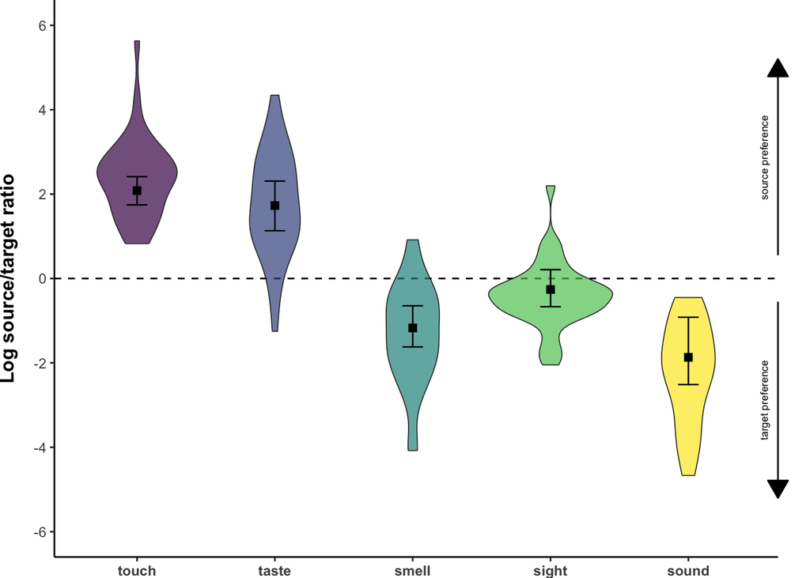

```r
# Core of plot:

ratio_p <- ratios_long %>%
  ggplot(aes(x = modality)) +
  geom_hline(yintercept = 0, linetype = 'dashed') +
  geom_violin(aes(y = log_ratio),
              alpha = 0,
              color = NA) +
  geom_violin(aes(fill = modality,
                    y = log_ratio),
              alpha = 0.7,
              linewidth = 0.3) +
  geom_errorbar(data = fixefs,
                mapping = aes(x = modality,
                              ymin = lower_CI, ymax = upper_CI),
                linewidth = 0.45,
                width = 0.15) +
  geom_point(pch = 15, size = 2.2,
             data = fixefs,
             mapping = aes(y = estimate))

# Add annotations, axes, labels to plot:

ratio_p <- ratio_p +
  coord_cartesian(clip = 'off') +
  xlab(NULL) +
  ylab('Log source/target ratio') +
  scale_fill_viridis_d(option = 'D') +
  scale_y_continuous(limits = c(-6, 6),
                     breaks = seq(-6, 6, 2)) +
  annotate('text',
           label = 'source preference',
           x = 5.55, hjust = 0.5,
           y = (0.55 + 5.2) / 2, size = 2.3,
           angle = 90) +
  annotate('text',
           label = 'target preference',
           x = 5.55, hjust = 0.5, angle = 90,
           y = (-0.55 + -5.2) / 2, size = 2.3) +
  annotate('segment', y = 0.55, yend = 5.2,
           x = 5.65, xend = 5.65,
           arrow = arrow(type = 'closed', length = unit(0.036, 'npc'))) +
  annotate('segment', y = -0.55, yend = -5.2,
           x = 5.65, xend = 5.65,
           arrow = arrow(type = 'closed', length = unit(0.036, 'npc')))

# Cosmetic tweaking:

ratio_p <- ratio_p +
  theme_classic() +
  theme(legend.position = 'none',
        axis.text.x = element_text(face = 'bold'),
        axis.title = element_text(face = 'bold',
                                  size = 12),
        axis.title.y = element_text(margin = margin(r = 10)),
        plot.margin = margin(r = 20))

# Show plot in markdown and also save externally outside of R:

ratio_p
```

```r
ggsave(plot = ratio_p,
       filename = '../figures/pdf/source_target_ratios_violin_with_95CI.pdf',
       width = 5.2, height = 3.5)
ggsave(plot = ratio_p,
       filename = '../figures/png/source_target_ratios_violin_with_95CI.png',
       width = 5.2, height = 3.5)
```

# 7 Hypotheses tests for conditions

With the new `posts` object, we can easily perform hypothesis tests to look at which modalities differ reliably in their source/target ratio means.

```r
# Touch against rest:

sum(with(posts, touch > taste)) / nrow(posts)
```

```
## [1] 0.87525
```

```r
sum(with(posts, touch > smell)) / nrow(posts)
```

```
## [1] 1
```

```r
sum(with(posts, touch > sight)) / nrow(posts)
```

```
## [1] 1
```

```r
sum(with(posts, touch > sound)) / nrow(posts)
```

```
## [1] 1
```

```r
# Taste against rest:

sum(with(posts, taste > smell)) / nrow(posts)
```

```
## [1] 1
```

```r
sum(with(posts, taste > sight)) / nrow(posts)
```

```
## [1] 1
```

```r
sum(with(posts, taste > sound)) / nrow(posts)
```

```
## [1] 1
```

```r
# Smell against rest:

sum(with(posts, smell < sight)) / nrow(posts) # smell lower than sight
```

```
## [1] 0.992875
```

```r
sum(with(posts, smell > sound)) / nrow(posts)
```

```
## [1] 0.932125
```

```r
# Sight against rest:

sum(with(posts, sight > sound)) / nrow(posts)
```

```
## [1] 0.9945
```

# 8 Calculate target entropy

Let’s calculate the entropy to get a measure of the diversity of targets across cells. We will add +1 to get rid of `Inf` for those cases that are zero. Since this is applied to *all* cells, it shouldn’t bias the results with respect to any one modality.

```r
# Setup tibble with empty columns:

entropies <- tibble(dataset = names(both_tables),
                    touch = NA,
                    taste = NA,
                    smell = NA,
                    sight = NA,
                    sound = NA)

# Vector of modalities:

mods <- c('touch', 'taste', 'smell', 'sight', 'sound')

# Loop through tables, compute proportions, and save in results table:

for (i in seq_along(both_tables)) {
  # Extract table from list and transform into matrix object without first column:

  M <- both_tables[[i]]

  # All ratios:

  for (j in 1:nrow(M)) {
    this_row <- M[j, ]
    this_row <- this_row[!is.na(this_row)]
    this_row <- this_row + 1 # to get rid of Inf for log
    ps <- this_row / sum(this_row)
    entropies[i, mods[j]] <- sum(ps * log(ps)) * -1
  }
}
```

Make that into a long format table so we can plot it:

```r
entro_df <- entropies %>%
  pivot_longer(cols = touch:sound,
               names_to = 'modality',
               values_to = 'entropy')

# Check:

entro_df
```

```
## # A tibble: 190 × 3
##    dataset                       modality entropy
##    <chr>                         <chr>      <dbl>
##  1 bretones-callejas_2001_heaney touch      1.21
##  2 bretones-callejas_2001_heaney taste      1.28
##  3 bretones-callejas_2001_heaney smell      1.33
##  4 bretones-callejas_2001_heaney sight      1.24
##  5 bretones-callejas_2001_heaney sound      1.03
##  6 day_1996_english              touch      0.735
##  7 day_1996_english              taste      1.18
##  8 day_1996_english              smell      1.33
##  9 day_1996_english              sight      0.910
## 10 day_1996_english              sound      0.700
## # ℹ 180 more rows
```

Check averages:

```r
entro_df %>%
  group_by(modality) %>%
  summarize(M = mean(entropy, na.rm = TRUE)) |>
  arrange(desc(M))
```

```
## # A tibble: 5 × 2
##   modality     M
##   <chr>    <dbl>
## 1 smell    1.24
## 2 taste    1.19
## 3 touch    1.01
## 4 sight    1.00
## 5 sound    0.779
```

Make the order of the `modality` factor roughly correspond to the hierarchy for plotting purposes:

```r
# Define vector with desired order:

level_order <- c('touch', 'taste', 'smell', 'sight', 'sound')

# Make column into factor with those levels:

entro_df <- mutate(entro_df,
                     modality = factor(modality,
                                       levels = level_order))
```

Make a plot of this:

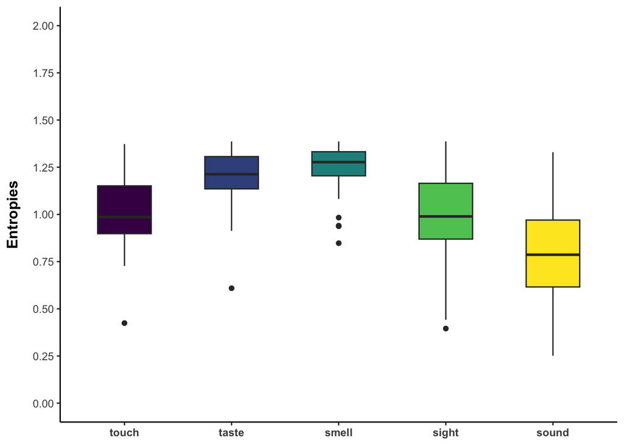

```r
# Core of plot:

entro_p <- entro_df %>%
  ggplot(aes(x = modality,
             y = entropy,
             fill = modality)) +
  geom_boxplot(width = 0.5)

# Add annotations, axes, labels to plot:

entro_p <- entro_p +
  xlab(NULL) +
  ylab('Entropies') +
  scale_fill_viridis_d(option = 'D') +
  scale_y_continuous(limits = c(0, 2),
                     breaks = seq(0, 2, 0.25))

# Cosmetic tweaking:

entro_p <- entro_p +
  theme_classic() +
  theme(legend.position = 'none',
        axis.text.x = element_text(face = 'bold'),
        axis.title = element_text(face = 'bold',
                                  size = 12),
        axis.title.y = element_text(margin = margin(r = 10)))

# Show plot in markdown and also save externally outside of R:

entro_p
```

```r
ggsave(plot = entro_p,
       filename = '../figures/pdf/target_entropies.pdf',
       width = 5.2, height = 4.5)
ggsave(plot = entro_p,
       filename = '../figures/png/target_entropies.png',
       width = 5.2, height = 4.5)
```

Merge metadata back in:

```r
entro_df <- left_join(entro_df,
                      select(metadata, table_title, genre, language),
                      by = c('dataset' = 'table_title'))
```

Set priors. We’ll make the normal prior for the coefficients a bit more narrow given that the entropy scale is very small.

```r
my_priors <- c(prior(normal(0, 1), class = Intercept),
               prior(normal(0, 0.5), class = b),
               prior(student_t(3, 0, 2.5), class = sd), # df = 3, mu = 0, sigma = 2.5
               prior(lkj(2), class = cor))
```

Fit a Gaussian model then:

```r
entropy_mdl <- brm(entropy ~
                     # Fixed effects:

                     1 + modality +

                     # Random effects:

                     (1 + modality|language),

                   data = entro_df,
                   family = gaussian,

                   # Priors:

                   prior = my_priors,

                   # MCMC settings:

                   seed = 42, cores = 4, chains = 4,
                   iter = 6000, warmup = 4000,
                   control = list(adapt_delta = 0.99),
                   save_pars = save_pars(all = TRUE))
```

```
## Trying to compile a simple C file
```

[output not shown]

```r
# Save the model:

save(entropy_mdl, file = '../models/entropy_mdl.RData')
```

Load the pre-compiled model:

```r
load('../models/entropy_mdl.RData')
```

Assess whether this is a plausible data-generating process:

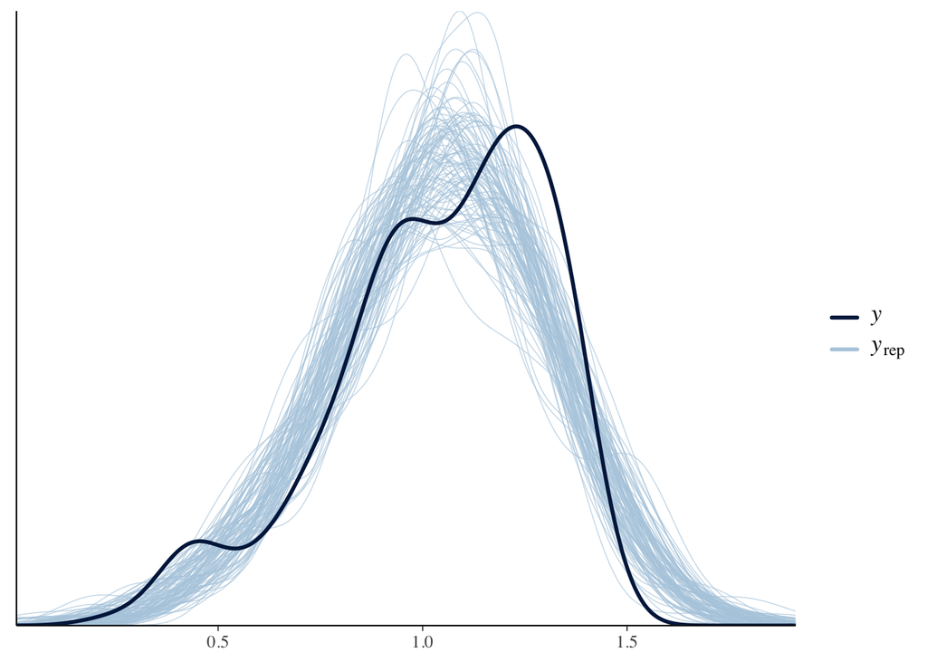

```r
pp_check(entropy_mdl, ndraws = 100)
```

Looks OK.

Check the model:

```r
entropy_mdl
```

```
##  Family: gaussian
##   Links: mu = identity; sigma = identity
## Formula: entropy ~ 1 + modality + (1 + modality | language)
##    Data: entro_df (Number of observations: 190)
##   Draws: 4 chains, each with iter = 6000; warmup = 4000; thin = 1;
##          total post-warmup draws = 8000
##
## Group-Level Effects:
## ~language (Number of levels: 14)
##                                  Estimate Est.Error l-95% CI u-95% CI Rhat
## sd(Intercept)                        0.10      0.05     0.02     0.21 1.00
## sd(modalitytaste)                    0.06      0.04     0.00     0.16 1.00
## sd(modalitysmell)                    0.05      0.04     0.00     0.14 1.00
## sd(modalitysight)                    0.18      0.08     0.04     0.35 1.00
## sd(modalitysound)                    0.16      0.07     0.04     0.30 1.00
## cor(Intercept,modalitytaste)         0.04      0.35    -0.64     0.69 1.00
## cor(Intercept,modalitysmell)        -0.02      0.35    -0.68     0.66 1.00
## cor(modalitytaste,modalitysmell)     0.04      0.36    -0.64     0.69 1.00
## cor(Intercept,modalitysight)         0.29      0.30    -0.34     0.79 1.00
## cor(modalitytaste,modalitysight)     0.08      0.36    -0.61     0.74 1.00
## cor(modalitysmell,modalitysight)     0.08      0.36    -0.62     0.72 1.00
## cor(Intercept,modalitysound)         0.00      0.32    -0.60     0.62 1.00
## cor(modalitytaste,modalitysound)    -0.04      0.35    -0.68     0.63 1.00
## cor(modalitysmell,modalitysound)     0.02      0.35    -0.64     0.67 1.00
## cor(modalitysight,modalitysound)     0.32      0.30    -0.35     0.81 1.00
##                                  Bulk_ESS Tail_ESS
## sd(Intercept)                        1921     1721
## sd(modalitytaste)                    3091     3513
## sd(modalitysmell)                    4563     4184
## sd(modalitysight)                    2398     2327
## sd(modalitysound)                    2596     2586
## cor(Intercept,modalitytaste)        11331     6108
## cor(Intercept,modalitysmell)        11580     5824
## cor(modalitytaste,modalitysmell)     8292     6233
## cor(Intercept,modalitysight)         4428     4862
## cor(modalitytaste,modalitysight)     2548     4051
## cor(modalitysmell,modalitysight)     3321     5485
## cor(Intercept,modalitysound)         5509     5990
## cor(modalitytaste,modalitysound)     3150     4767
## cor(modalitysmell,modalitysound)     3461     5613
## cor(modalitysight,modalitysound)     5261     5975
##
## Population-Level Effects:
##               Estimate Est.Error l-95% CI u-95% CI Rhat Bulk_ESS Tail_ESS
## Intercept         1.01      0.04     0.92     1.09 1.00     3754     4381
## modalitytaste     0.18      0.04     0.08     0.26 1.00     6918     6008
## modalitysmell     0.23      0.04     0.14     0.31 1.00     7331     6085
## modalitysight    -0.00      0.07    -0.14     0.13 1.00     3860     3969
## modalitysound    -0.22      0.06    -0.34    -0.09 1.00     4798     4996
##
## Family Specific Parameters:
##       Estimate Est.Error l-95% CI u-95% CI Rhat Bulk_ESS Tail_ESS
## sigma     0.17      0.01     0.15     0.19 1.00     5575     5556
##
## Draws were sampled using sampling(NUTS). For each parameter, Bulk_ESS
## and Tail_ESS are effective sample size measures, and Rhat is the potential
## scale reduction factor on split chains (at convergence, Rhat = 1).
```

Get the predictions:

```r
entropy_preds <- entropy_mdl |>
  spread_draws(b_Intercept, b_modalitytaste, b_modalitysmell,
               b_modalitysight, b_modalitysound) |>
  select(-(.chain:.draw)) |>
  mutate(touch = b_Intercept,
         taste = b_Intercept + b_modalitytaste,
         smell = b_Intercept + b_modalitysmell,
         sight = b_Intercept + b_modalitysight,
         sound = b_Intercept + b_modalitysound) |>
  select(-(b_Intercept:b_modalitysound))

# Show:

entropy_preds
```

```
## # A tibble: 8,000 × 5
##    touch taste smell sight sound
##    <dbl> <dbl> <dbl> <dbl> <dbl>
##  1 0.967  1.15  1.25 0.986 0.717
##  2 1.05   1.17  1.28 0.954 0.843
##  3 1.01   1.18  1.30 0.994 0.799
##  4 0.989  1.24  1.20 1.03  0.683
##  5 1.02   1.15  1.27 1.00  0.748
##  6 1.00   1.15  1.23 0.978 0.798
##  7 1.05   1.12  1.27 1.05  0.834
##  8 1.00   1.15  1.25 1.06  0.801
##  9 0.965  1.25  1.21 1.01  0.786
## 10 1.00   1.23  1.30 1.03  0.848
## # ℹ 7,990 more rows
```

Perform hypotheses tests with these posterior samples:

```r
sum(entropy_preds$touch < entropy_preds$taste) / nrow(entropy_preds)
```

```
## [1] 0.99975
```

```r
sum(entropy_preds$touch < entropy_preds$smell) / nrow(entropy_preds)
```

```
## [1] 1
```

We are very certain that taste and smell attach to a wider range of targets than touch.

Next, let’s compare touch to the “higher” senses of sight and sound:

```r
sum(entropy_preds$touch > entropy_preds$sight) / nrow(entropy_preds)
```

```
## [1] 0.50475
```

```r
sum(entropy_preds$touch > entropy_preds$sound) / nrow(entropy_preds)
```

```
## [1] 0.99875
```

There is no difference between touch and sight, but touch has more target modality entropy than sound: it attaches to a wider range of targets.

Do taste and smell differ from each other?

```r
sum(entropy_preds$taste < entropy_preds$smell) / nrow(entropy_preds)
```

```
## [1] 0.869
```

Can’t be that certain about any difference.

What about taste and the “higher” senses?

```r
sum(entropy_preds$taste > entropy_preds$sight) / nrow(entropy_preds)
```

```
## [1] 0.992875
```

```r
sum(entropy_preds$taste > entropy_preds$sound) / nrow(entropy_preds)
```

```
## [1] 1
```

We can be very certain it has a bigger entropy. Same for smell.

```r
sum(entropy_preds$smell > entropy_preds$sight) / nrow(entropy_preds)
```

```
## [1] 0.9985
```

```r
sum(entropy_preds$smell > entropy_preds$sound) / nrow(entropy_preds)
```

```
## [1] 1
```

Yup, same.

And do we have a lot of certainty in sight having higher entropies than sound?

```r
sum(entropy_preds$sight > entropy_preds$sound) / nrow(entropy_preds)
```

```
## [1] 0.99525
```

Yes.

# 9 Entropy plot

Get the posterior samples from the model:

```r
posts <- entropy_mdl |>
  spread_draws(b_Intercept, b_modalitytaste,
               b_modalitysmell, b_modalitysight,
               b_modalitysound)
```

Fill out the regression equation for all five cells of the stats:

```r
posts <- posts |>
  mutate(taste = b_Intercept + b_modalitytaste,
         smell = b_Intercept + b_modalitysmell,
         sight = b_Intercept + b_modalitysight,
         sound = b_Intercept + b_modalitysound) |>
  rename(touch = b_Intercept) |>
  select(-(b_modalitytaste:b_modalitysound),
         -(.chain:.draw))

# Show:

posts
```

```
## # A tibble: 8,000 × 5
##    touch taste smell sight sound
##    <dbl> <dbl> <dbl> <dbl> <dbl>
##  1 0.967  1.15  1.25 0.986 0.717
##  2 1.05   1.17  1.28 0.954 0.843
##  3 1.01   1.18  1.30 0.994 0.799
##  4 0.989  1.24  1.20 1.03  0.683
##  5 1.02   1.15  1.27 1.00  0.748
##  6 1.00   1.15  1.23 0.978 0.798
##  7 1.05   1.12  1.27 1.05  0.834
##  8 1.00   1.15  1.25 1.06  0.801
##  9 0.965  1.25  1.21 1.01  0.786
## 10 1.00   1.23  1.30 1.03  0.848
## # ℹ 7,990 more rows
```

Compute relevant stats… need to make it long format for that:

```r
posts_long <- posts |>
  pivot_longer(cols = touch:sound,
               names_to = 'modality',
               values_to = 'log_ratio') |>
  arrange(modality)

# Show long format:

posts_long
```

```
## # A tibble: 40,000 × 2
##    modality log_ratio
##    <chr>        <dbl>
##  1 sight        0.986
##  2 sight        0.954
##  3 sight        0.994
##  4 sight        1.03
##  5 sight        1.00
##  6 sight        0.978
##  7 sight        1.05
##  8 sight        1.06
##  9 sight        1.01
## 10 sight        1.03
## # ℹ 39,990 more rows
```

Compute 95% credible interval and means:

```r
fixefs <- posts_long |>
  group_by(modality) |>
  summarize(lower_CI = quantile(log_ratio, 0.025),
            upper_CI = quantile(log_ratio, 0.975),
            estimate = mean(log_ratio))

# Show:

fixefs
```

```
## # A tibble: 5 × 4
##   modality lower_CI upper_CI estimate
##   <chr>       <dbl>    <dbl>    <dbl>
## 1 sight       0.851    1.16     1.01
## 2 smell       1.14     1.33     1.24
## 3 sound       0.666    0.918    0.789
## 4 taste       1.09     1.28     1.18
## 5 touch       0.923    1.09     1.01
```

Make a beeswarm or violin plot:

```r
# Core of plot:

entro_p <- entro_df %>%
  ggplot(aes(x = modality)) +
  geom_violin(aes(y = entropy),
              alpha = 0,
              color = NA) +
  geom_violin(aes(fill = modality,
                    y = entropy),
              alpha = 0.7,
              linewidth = 0.3) +
  geom_errorbar(data = fixefs,
                mapping = aes(x = modality,
                              ymin = lower_CI, ymax = upper_CI),
                linewidth = 0.45,
                width = 0.15) +
  geom_point(pch = 15, size = 2.2,
             data = fixefs,
             mapping = aes(y = estimate))
NULL
```

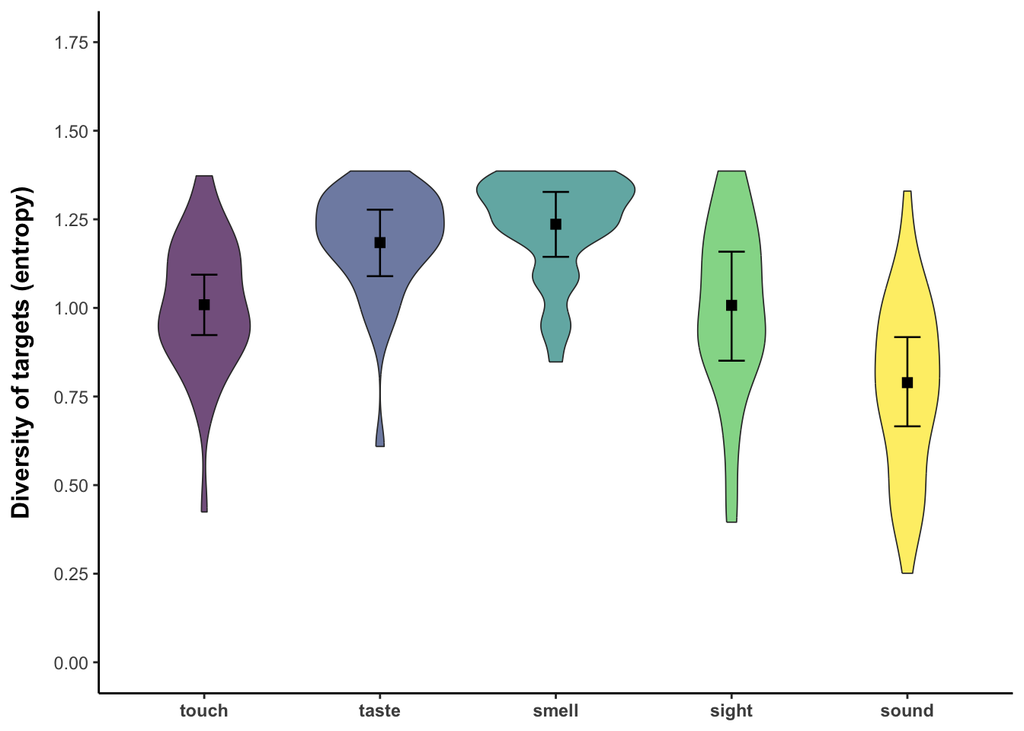

```r
# Add annotations, axes, labels to plot:

entro_p <- entro_p +
  xlab(NULL) +
  ylab('Diversity of targets (entropy)') +
  scale_fill_viridis_d(option = 'D') +
  scale_y_continuous(limits = c(0, 1.75),
                     breaks = seq(0, 1.75, 0.25))

# Cosmetic tweaking:

entro_p <- entro_p +
  theme_classic() +
  theme(legend.position = 'none',
        axis.text.x = element_text(face = 'bold'),
        axis.title = element_text(face = 'bold',
                                  size = 12),
        axis.title.y = element_text(margin = margin(r = 10)))

# Show plot in markdown and also save externally outside of R:

entro_p
```

```r
ggsave(plot = entro_p,
       filename = '../figures/pdf/entropies_violin_with_95CI.pdf',
       width = 5.2, height = 3.5)
ggsave(plot = entro_p,
       filename = '../figures/png/entropies_violin_with_95CI.png',
       width = 5.2, height = 3.5)
```

# 10 Correlation between ratio and entropy

Check that the two can be merged:

```r
all(ratios_long$dataset == entro_df$dataset)
```

```
## [1] TRUE
```

```r
all(ratios_long$modality == entro_df$modality)
```

```
## [1] TRUE
```

Correlate the two:

```r
both_df <- bind_cols(select(ratios_long, dataset, language, modality, ratio, log_ratio),
                     select(entro_df, entropy))
```

See whether they are correlated, simple correlation that ignores all dependencies:

```r
with(both_df,
     cor.test(log_ratio, entropy, method = 'pearson'))
```

```
##
##  Pearson's product-moment correlation
##
## data:  log_ratio and entropy
## t = 2.7606, df = 172, p-value = 0.006396
## alternative hypothesis: true correlation is not equal to 0
## 95 percent confidence interval:
##  0.05901592 0.34419977
## sample estimates:
##       cor
## 0.2059773
```

What about the averages, are they correlated?

```r
both_tab <- both_df |>
  group_by(modality) |>
  summarize(mean_ratio = mean(log_ratio, na.rm = TRUE),
            mean_entro = mean(entropy))

both_tab
```

```
## # A tibble: 5 × 3
##   modality mean_ratio mean_entro
##   <fct>         <dbl>      <dbl>
## 1 touch         2.37       1.01
## 2 taste         1.75       1.19
## 3 smell        -1.32       1.24
## 4 sight        -0.393      1.00
## 5 sound        -2.20       0.779
```

```r
with(both_tab, cor.test(mean_ratio, mean_entro))
```

```
##
##  Pearson's product-moment correlation
##
## data:  mean_ratio and mean_entro
## t = 0.6709, df = 3, p-value = 0.5503
## alternative hypothesis: true correlation is not equal to 0
## 95 percent confidence interval:
##  -0.7647871  0.9429659
## sample estimates:
##       cor
## 0.3611925
```

Somewhat correlated.

This completes this analysis.